```python
import numpy as np
import pandas as pd
import matplotlib.pyplot as plt
import seaborn as sns
from sklearn.linear_model import LogisticRegression
from sklearn.svm import SVC
from sklearn.neighbors import KNeighborsClassifier
from sklearn.tree import DecisionTreeClassifier
from sklearn.naive_bayes import GaussianNB
from sklearn.model_selection import train_test_split, GridSearchCV, StratifiedKFold, KFold
from sklearn.preprocessing import MinMaxScaler,StandardScaler,OneHotEncoder
from imblearn.over_sampling import SMOTE,RandomOverSampler
from imblearn.pipeline import Pipeline as imbpipeline
from sklearn.pipeline import Pipeline
from sklearn.metrics import recall_score, precision_score,precision_recall_curve, accuracy_score,classification_report
from sklearn.metrics import confusion_matrix, roc_curve, auc
import joblib
import warnings
warnings.filterwarnings('ignore')
```

```python
#!pip install --user imbalanced-learn
```

# Reading Loan Dataset

```python
df=pd.read_csv("loan_data_set.csv")
```

```python
df.head()
```

|  | Loan_ID | Gender | Married | Dependents | Education | Self_Employed | ApplicantIncome | CoapplicantIncome | LoanAmount | Loan_Amount_Term | Credit_History | Loan_Status |
| --- | --- | --- | --- | --- | --- | --- | --- | --- | --- | --- | --- | --- |
| 0 | LP001002 | Male | No | 0 | Graduate | No | 5849 | 0.0 | NaN | 360.0 | 1.0 | Y |
| 1 | LP001003 | Male | Yes | 1 | Graduate | No | 4583 | 1508.0 | 128.0 | 360.0 | 1.0 | N |
| 2 | LP001005 | Male | Yes | 0 | Graduate | Yes | 3000 | 0.0 | 66.0 | 360.0 | 1.0 | Y |
| 3 | LP001006 | Male | Yes | 0 | Not Graduate | No | 2583 | 2358.0 | 120.0 | 360.0 | 1.0 | Y |
| 4 | LP001008 | Male | No | 0 | Graduate | No | 6000 | 0.0 | 141.0 | 360.0 | 1.0 | Y |

## Displaying Number Of Samples in Dataset

```python
len(df)
```

```
614
```

```python
df.info()
```

```
<class 'pandas.core.frame.DataFrame'>
RangeIndex: 614 entries, 0 to 613
Data columns (total 12 columns):
 #   Column             Non-Null Count  Dtype
---  ------             --------------  -----
 0   Loan_ID            614 non-null    object
 1   Gender             601 non-null    object
 2   Married            611 non-null    object
 3   Dependents         599 non-null    object
 4   Education          614 non-null    object
 5   Self_Employed      582 non-null    object
 6   ApplicantIncome    614 non-null    int64
 7   CoapplicantIncome  614 non-null    float64
 8   LoanAmount         592 non-null    float64
 9   Loan_Amount_Term   600 non-null    float64
 10  Credit_History     564 non-null    float64
 11  Loan_Status        614 non-null    object
dtypes: float64(4), int64(1), object(7)
memory usage: 57.7+ KB
```

```python
df.describe()
```

|  | ApplicantIncome | CoapplicantIncome | LoanAmount | Loan_Amount_Term | Credit_History |
| --- | --- | --- | --- | --- | --- |
| count | 614.000000 | 614.000000 | 592.000000 | 600.00000 | 564.000000 |
| mean | 5403.459283 | 1621.245798 | 146.412162 | 342.00000 | 0.842199 |
| std | 6109.041673 | 2926.248369 | 85.587325 | 65.12041 | 0.364878 |
| min | 150.000000 | 0.000000 | 9.000000 | 12.00000 | 0.000000 |
| 25% | 2877.500000 | 0.000000 | 100.000000 | 360.00000 | 1.000000 |
| 50% | 3812.500000 | 1188.500000 | 128.000000 | 360.00000 | 1.000000 |
| 75% | 5795.000000 | 2297.250000 | 168.000000 | 360.00000 | 1.000000 |
| max | 81000.000000 | 41667.000000 | 700.000000 | 480.00000 | 1.000000 |

```python
df.describe(include=[object])
```

|  | Loan_ID | Gender | Married | Dependents | Education | Self_Employed | Loan_Status |
| --- | --- | --- | --- | --- | --- | --- | --- |
| count | 614 | 601 | 611 | 599 | 614 | 582 | 614 |
| unique | 614 | 2 | 2 | 4 | 2 | 2 | 2 |
| top | LP001326 | Male | Yes | 0 | Graduate | No | Y |
| freq | 1 | 489 | 398 | 345 | 480 | 500 | 422 |

```python
df.info()
```

```
<class 'pandas.core.frame.DataFrame'>
RangeIndex: 614 entries, 0 to 613
Data columns (total 12 columns):
 #   Column             Non-Null Count  Dtype
---  ------             --------------  -----
 0   Loan_ID            614 non-null    object
 1   Gender             601 non-null    object
 2   Married            611 non-null    object
 3   Dependents         599 non-null    object
 4   Education          614 non-null    object
 5   Self_Employed      582 non-null    object
 6   ApplicantIncome    614 non-null    int64
 7   CoapplicantIncome  614 non-null    float64
 8   LoanAmount         592 non-null    float64
 9   Loan_Amount_Term   600 non-null    float64
 10  Credit_History     564 non-null    float64
 11  Loan_Status        614 non-null    object
dtypes: float64(4), int64(1), object(7)
memory usage: 57.7+ KB
```

## Plotting box

#### We can see that there are lots of Outliers in the ApplicantIncome and CoapplicantIncome columns.

#### We need to remove them in the next preprocessing step

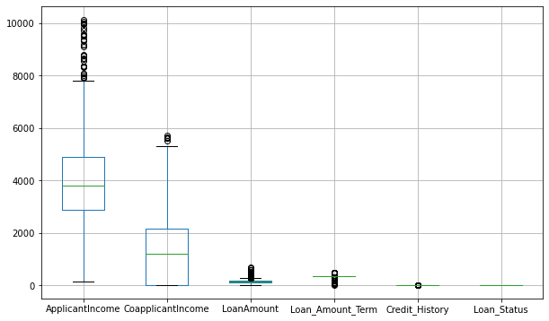

```python
df.boxplot(figsize=(10, 6))
```

## Frequency Of Columns

```
array([[<AxesSubplot:title={'center':'CoapplicantIncome'}>,
        <AxesSubplot:title={'center':'ApplicantIncome'}>],
       [<AxesSubplot:title={'center':'LoanAmount'}>,
        <AxesSubplot:title={'center':'Loan_Amount_Term'}>],
       [<AxesSubplot:title={'center':'Credit_History'}>, <AxesSubplot:>]],
      dtype=object)
```

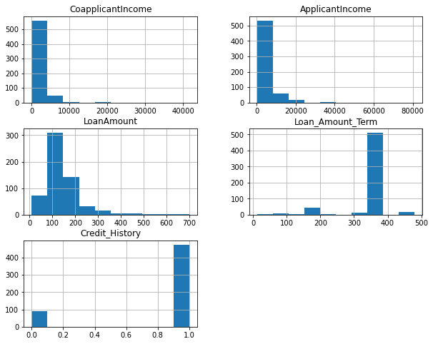

```python
df.hist(column=['CoapplicantIncome','ApplicantIncome','LoanAmount','Loan_Amount_Term','Credit_History','Loan_Status'],figsize=(10, 8))
```

## Plotting Pie of ApplicantIncome & CoapplicantIncome & LoanAmount & Loan_Amount_Term & Credit_History Columns

```
array([<AxesSubplot:ylabel='ApplicantIncome'>,
       <AxesSubplot:ylabel='CoapplicantIncome'>,
       <AxesSubplot:ylabel='LoanAmount'>,
       <AxesSubplot:ylabel='Loan_Amount_Term'>,
       <AxesSubplot:ylabel='Credit_History'>], dtype=object)
```

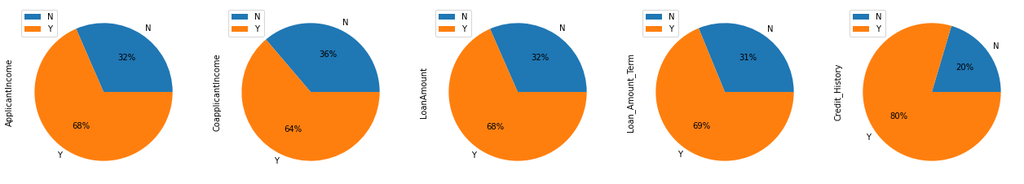

```python
df.groupby(['Loan_Status']).sum().plot(kind='pie', figsize=(22, 9), subplots=True,autopct='%1.0f%%')
```

# Preprocessing Dataset

### Deleting Loan_ID Column using drop()

```python
df.drop(columns=['Loan_ID'],inplace=True)
df.head()
```

|  | Gender | Married | Dependents | Education | Self_Employed | ApplicantIncome | CoapplicantIncome | LoanAmount | Loan_Amount_Term | Credit_History | Loan_Status |
| --- | --- | --- | --- | --- | --- | --- | --- | --- | --- | --- | --- |
| 0 | Male | No | 0 | Graduate | No | 5849 | 0.0 | 146.412162 | 360.0 | 1.0 | 1 |
| 1 | Male | Yes | 1 | Graduate | No | 4583 | 1508.0 | 128.000000 | 360.0 | 1.0 | 0 |
| 2 | Male | Yes | 0 | Graduate | Yes | 3000 | 0.0 | 66.000000 | 360.0 | 1.0 | 1 |
| 3 | Male | Yes | 0 | Not Graduate | No | 2583 | 2358.0 | 120.000000 | 360.0 | 1.0 | 1 |
| 4 | Male | No | 0 | Graduate | No | 6000 | 0.0 | 141.000000 | 360.0 | 1.0 | 1 |

### Displaying the unique values of each column in Dataset

```python
def uniqueValueOfDF():
    for col in df:
        print("--------------------------")
        print("Unique values of",col,"column:")
        print(list(df[col].unique()))
    print("--------------------------")
    df.info()
    print("--------------------------")
```

#### We notice that there are some null values in most of the columns

## Converting nan-values into mean and mode values

```python
def ConNanToMeanAndMode():
    nan_cols_mode=["Gender","Married","Dependents","Self_Employed","Loan_Amount_Term","Credit_History"]
    for col in nan_cols_mode:
        df[col].fillna(df[col].mode()[0],inplace=True)
    df["LoanAmount"].fillna(df["LoanAmount"].mean(),inplace=True)
    #Converting '3+' value into '3' value in Dependents Column
    df["Dependents"].replace('3+','3',inplace=True)
    df['Loan_Status'].replace('N',0,inplace=True)
    df['Loan_Status'].replace('Y',1,inplace=True)
    uniqueValueOfDF()
ConNanToMeanAndMode()
```

```
--------------------------
Unique values of Gender column:
['Male', 'Female']
--------------------------
Unique values of Married column:
['No', 'Yes']
--------------------------
Unique values of Dependents column:
['0', '1', '2', '3']
--------------------------
Unique values of Education column:
['Graduate', 'Not Graduate']
--------------------------
Unique values of Self_Employed column:
['No', 'Yes']
--------------------------
Unique values of ApplicantIncome column:
[5849, 4583, 3000, 2583, 6000, 5417, 2333, 3036, 4006, 12841, 3200, 2500, 3073, 1853, 1299, 4950, 3596, 3510, 4887, 2600, 7660, 5955, 3365, 3717, 9560, 2799, 4226, 1442, 3750, 4166, 3167, 4692, 3500, 12500, 2275, 1828, 3667, 3748, 3600, 1800, 2400, 3941, 4695, 3410, 5649, 5821, 2645, 4000, 1928, 308…
--------------------------
Unique values of CoapplicantIncome column:
[0.0, 1508.0, 2358.0, 4196.0, 1516.0, 2504.0, 1526.0, 10968.0, 700.0, 1840.0, 8106.0, 2840.0, 1086.0, 3500.0, 5625.0, 1911.0, 1917.0, 2925.0, 2253.0, 1040.0, 2083.0, 3369.0, 1667.0, 3000.0, 2067.0, 1330.0, 1459.0, 7210.0, 1668.0, 1213.0, 2336.0, 3440.0, 2275.0, 1644.0, 1167.0, 1591.0, 2200.0, 2250.0…
--------------------------
Unique values of LoanAmount column:
[146.41216216216216, 128.0, 66.0, 120.0, 141.0, 267.0, 95.0, 158.0, 168.0, 349.0, 70.0, 109.0, 200.0, 114.0, 17.0, 125.0, 100.0, 76.0, 133.0, 115.0, 104.0, 315.0, 116.0, 112.0, 151.0, 191.0, 122.0, 110.0, 35.0, 201.0, 74.0, 106.0, 320.0, 144.0, 184.0, 80.0, 47.0, 75.0, 134.0, 96.0, 88.0, 44.0, 286.0…
--------------------------
Unique values of Loan_Amount_Term column:
[360.0, 120.0, 240.0, 180.0, 60.0, 300.0, 480.0, 36.0, 84.0, 12.0]
--------------------------
Unique values of Credit_History column:
[1.0, 0.0]
--------------------------
Unique values of Loan_Status column:
[1, 0]
--------------------------
<class 'pandas.core.frame.DataFrame'>
RangeIndex: 614 entries, 0 to 613
Data columns (total 11 columns):
 #   Column             Non-Null Count  Dtype
---  ------             --------------  -----
 0   Gender             614 non-null    object
 1   Married            614 non-null    object
 2   Dependents         614 non-null    object
 3   Education          614 non-null    object
 4   Self_Employed      614 non-null    object
 5   ApplicantIncome    614 non-null    int64
 6   CoapplicantIncome  614 non-null    float64
 7   LoanAmount         614 non-null    float64
 8   Loan_Amount_Term   614 non-null    float64
 9   Credit_History     614 non-null    float64
 10  Loan_Status        614 non-null    int64
dtypes: float64(4), int64(2), object(5)
memory usage: 52.9+ KB
--------------------------
```

## remove outliers from ApplicantIncome and CoapplicantIncome columns

```python
def outlier_removal(col,factor=1.5):
    import numpy as np
    X = col.copy()
    q1 = X.quantile(0.25)
    q3 = X.quantile(0.75)
    iqr = q3 - q1
    lower_bound = q1 - (factor * iqr)
    upper_bound = q3 + (factor * iqr)
    X.loc[((X < lower_bound) | (X > upper_bound))] = np.nan
    avg_col=f'{X.mean():.1f}'
    avg_col=float(avg_col)
    #print(type(float(avg_col)))
    X=X.fillna(avg_col)
    #X.plot.box(figsize=(10, 9))
    return X
df['ApplicantIncome']=outlier_removal(df['ApplicantIncome'])
df['CoapplicantIncome']=outlier_removal(df['CoapplicantIncome'])
```

```
array([[<AxesSubplot:title={'center':'Loan_Status'}>]], dtype=object)
```

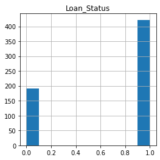

```python
df.hist(column=['Loan_Status'],figsize=(4, 4))
```

```python
cnt0=0
cnt1=0
for ele in df['Loan_Status']:
    if ele == 0:
        cnt0+=1
    else:
        cnt1+=1
print("class 0:",cnt0,"samples")
print("class 1:",cnt1,"samples")
```

```
class 0: 192 samples
class 1: 422 samples
```

#### We can notice the difference in number between class 0 and class 1, class 1(422 samples) have more examples than class 0 (192 samples)

## We have Imbalanced Dataset, we will use SMOTE (Synthetic Minority Oversampling Technique) to Handle it by synthesizing new examples from the existing examples

```python
X,y=df.loc[:,:"Credit_History"],df.loc[:,"Loan_Status"]
X=pd.get_dummies(X)
X.head()
```

|  | ApplicantIncome | CoapplicantIncome | LoanAmount | Loan_Amount_Term | Credit_History | Gender_Female | Gender_Male | Married_No | Married_Yes | Dependents_0 | Dependents_1 | Dependents_2 | Dependents_3 | Education_Graduate | Education_Not Graduate | Self_Employed_No | Self_Employed_Yes |
| --- | --- | --- | --- | --- | --- | --- | --- | --- | --- | --- | --- | --- | --- | --- | --- | --- | --- |
| 0 | 5849.0 | 0.0 | 146.412162 | 360.0 | 1.0 | 0 | 1 | 1 | 0 | 1 | 0 | 0 | 0 | 1 | 0 | 1 | 0 |
| 1 | 4583.0 | 1508.0 | 128.000000 | 360.0 | 1.0 | 0 | 1 | 0 | 1 | 0 | 1 | 0 | 0 | 1 | 0 | 1 | 0 |
| 2 | 3000.0 | 0.0 | 66.000000 | 360.0 | 1.0 | 0 | 1 | 0 | 1 | 1 | 0 | 0 | 0 | 1 | 0 | 0 | 1 |
| 3 | 2583.0 | 2358.0 | 120.000000 | 360.0 | 1.0 | 0 | 1 | 0 | 1 | 1 | 0 | 0 | 0 | 0 | 1 | 1 | 0 |
| 4 | 6000.0 | 0.0 | 141.000000 | 360.0 | 1.0 | 0 | 1 | 1 | 0 | 1 | 0 | 0 | 0 | 1 | 0 | 1 | 0 |

# Applying SMOTE to Handle Imbalanced Dataset

```python
smote = SMOTE(random_state = 11)
X, y = smote.fit_resample(X, y)
```

```python
cnt0=0
cnt1=0
for ele in y:
    if ele == 0:
        cnt0+=1
    else:
        cnt1+=1
print("class 0:",cnt0,"samples")
print("class 1:",cnt1,"samples")
```

```
class 0: 422 samples
class 1: 422 samples
```

## Now We have balanced Dataset , class 0 have (422 samples), class 1 have (422 samples)

## Splitting dataset into training (80%) and testing (20%) set

```python
X_train, X_test, y_train, y_test = train_test_split(X,y,test_size=0.2,stratify=y,random_state=11)
```

### training dataset samples

```python
len(X_train)
```

```
675
```

### testing dataset samples

```python
len(X_test)
```

```
169
```

# Training (Logistic Regression & SVM & KNN & Decision Tree & Gaussian Naive Bayes) Classifiers

#### we will use GridSearchCV for each classifier

##### which is exhaustive search over specified parameter values for an estimator

#### we will use StratifiedKFold

##### which provides train/test indices to split data in train/test sets.

##### and takes class information into account to avoid building folds with imbalanced class distributions (for binary or multiclass classification tasks).

#### we will use pipeline which implements utilities to build a composite estimator, as a chain of transforms and estimators

```
Logistic Regression Classifier

------------------------------
Cross-validation Accuracy: 0.8615765584108858
Test Accuracy: 0.8808290155440415
param_grid:  {'lr__C': [0.001, 0.01, 0.1, 1, 10, 100, 1000]}
best_estimator:  Pipeline(steps=[('scaler', StandardScaler()),
                ['lr',
                 LogisticRegression(C=1, max_iter=1000, random_state=11)]])
              precision    recall  f1-score   support

           N       1.00      0.73      0.84        84
           Y       0.79      1.00      0.88        85

    accuracy                           0.86       169
   macro avg       0.89      0.86      0.86       169
weighted avg       0.89      0.86      0.86       169

----------------------------------------
Plotting Precision-Recall Curve
-------------------------------
```

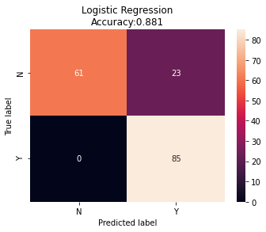

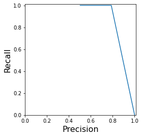

```
----------------------------------------
Plotting roc Curve

------------------
roc_lr:  0.8630952380952381
```

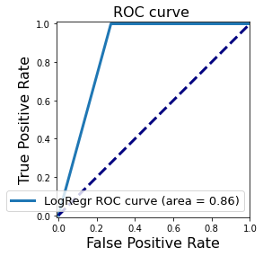

```
---------------------------------------------------------------------------------
SVC Classifier

--------------
Cross-validation Accuracy: 0.8640928144151426
Test Accuracy: 0.8762886597938144
param_grid:  {'SVC__kernel': ('rbf', 'linear'), 'SVC__C': [1, 2, 3, 5, 10, 15, 20]}
best_estimator:  Pipeline(steps=[('scaler', StandardScaler()),
                ['SVC', SVC(C=1, kernel='linear', random_state=11)]])
              precision    recall  f1-score   support

           N       1.00      0.71      0.83        84
           Y       0.78      1.00      0.88        85

    accuracy                           0.86       169
   macro avg       0.89      0.86      0.85       169
weighted avg       0.89      0.86      0.85       169

----------------------------------------
Plotting Precision-Recall Curve
-------------------------------
```

[figure not shown]

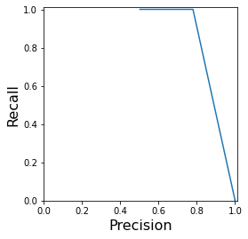

```
----------------------------------------
Plotting roc Curve

------------------
roc_lr:  0.8571428571428572
```

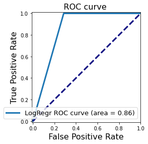

```
---------------------------------------------------------------------------------
KNeighbors Classifier

----------------------
Cross-validation Accuracy: 0.8079890904398118
Test Accuracy: 0.8253968253968255
param_grid:  [{'KNN__n_neighbors': [3, 5, 7, 9], 'KNN__weights': ['uniform', 'distance'], 'KNN__leaf_size': [15, 20]}]
best_estimator:  Pipeline(steps=[('scaler', StandardScaler()),
                ['KNN',
                 KNeighborsClassifier(leaf_size=15, n_neighbors=9,
                                      weights='distance')]])
              precision    recall  f1-score   support

           N       0.89      0.69      0.78        84
           Y       0.75      0.92      0.83        85

    accuracy                           0.80       169
   macro avg       0.82      0.80      0.80       169
weighted avg       0.82      0.80      0.80       169

----------------------------------------
Plotting Precision-Recall Curve
-------------------------------
```

[figure not shown]

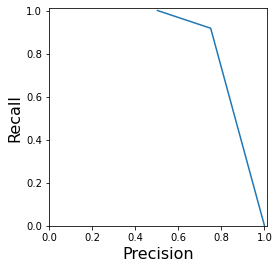

```
----------------------------------------
Plotting roc Curve

------------------
roc_lr:  0.80406162464986
```

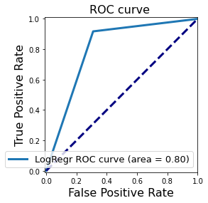

```
---------------------------------------------------------------------------------
Decision Tree Classifier

------------------------
Cross-validation Accuracy: 0.7709844584844584
Test Accuracy: 0.8170731707317074
param_grid:  {'DT__max_depth': (25, 50, 100, 150, 155, 160), 'DT__min_samples_split': (1, 2, 3), 'DT__min_samples_leaf': (1, 2, 3)}
best_estimator:  Pipeline(steps=[('scaler', StandardScaler()),
                ['DT',
                 DecisionTreeClassifier(criterion='entropy', max_depth=25,
                                        random_state=11)]])
              precision    recall  f1-score   support

           N       0.80      0.86      0.83        84
           Y       0.85      0.79      0.82        85

    accuracy                           0.82       169
   macro avg       0.82      0.82      0.82       169
weighted avg       0.82      0.82      0.82       169

----------------------------------------
Plotting Precision-Recall Curve
-------------------------------
```

[figure not shown]

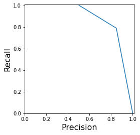

```
----------------------------------------
Plotting roc Curve

------------------
roc_lr:  0.8226890756302522
```

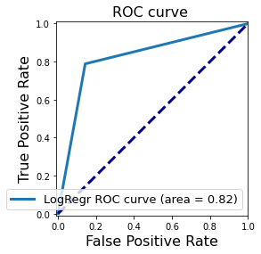

```
---------------------------------------------------------------------------------
Gaussian Naive Bayes Classifier

-------------------------------
Cross-validation Accuracy: 0.789390308717704
Test Accuracy: 0.7499999999999999
param_grid:  {'GNB__priors': [None, [0.1, 0.1]], 'GNB__var_smoothing': [1e-09, 1e-06, 1e-12]}
best_estimator:  Pipeline(steps=[('scaler', StandardScaler()), ['GNB', GaussianNB()]])
              precision    recall  f1-score   support

           N       0.74      0.76      0.75        84
           Y       0.76      0.74      0.75        85

    accuracy                           0.75       169
   macro avg       0.75      0.75      0.75       169
weighted avg       0.75      0.75      0.75       169

----------------------------------------
Plotting Precision-Recall Curve
-------------------------------
```

[3 more figures not shown]

```python
stratified_kfold = StratifiedKFold(n_splits=3,shuffle=True,random_state=11)

Classifiers=["Logistic Regression","SVC","KNN","Decision Tree","GaussianNB"]

for classifier in Classifiers:

    param_grid = {}
    pipeline = Pipeline(steps=[])

    if classifier == "Logistic Regression":
        print("Logistic Regression Classifier\n")
        print("------------------------------")
        pipeline = Pipeline(steps = [['scaler', StandardScaler()], #  MinMaxScaler()
                                     ['lr', LogisticRegression(random_state=11,max_iter=1000)]])
        param_grid = {'lr__C':[0.001, 0.01, 0.1, 1, 10, 100, 1000]}

    if classifier == "SVC":
        print("SVC Classifier\n")
        print("--------------")
        pipeline = Pipeline(steps = [['scaler', StandardScaler()], #  MinMaxScaler()
                                     ['SVC', SVC(random_state=11)]])
        param_grid = {'SVC__kernel':('rbf', 'linear'), 'SVC__C':[1,2,3,5,10,15,20]}

    if classifier == "KNN":
        print("KNeighbors Classifier\n")
        print("----------------------")
        pipeline = Pipeline(steps = [['scaler', StandardScaler()], #  MinMaxScaler()
                                     ['KNN', KNeighborsClassifier()]])
        param_grid = [{'KNN__n_neighbors': [3, 5, 7, 9],'KNN__weights': ['uniform', 'distance'],'KNN__leaf_size': [15, 20]}]

    if classifier == "Decision Tree":
        print("Decision Tree Classifier\n")
        print("------------------------")
        pipeline = Pipeline(steps = [['scaler', StandardScaler()], #  MinMaxScaler()
                                     ['DT', DecisionTreeClassifier(criterion='entropy',random_state=11)]])
        param_grid = {'DT__max_depth': (25,50,100,150, 155, 160),'DT__min_samples_split': (1, 2, 3),'DT__min_samples_leaf': (1, 2, 3)}

    if classifier == "GaussianNB":
        print("Gaussian Naive Bayes Classifier\n")
        print("-------------------------------")
        pipeline = Pipeline(steps = [['scaler', StandardScaler()], #  MinMaxScaler()
                                     ['GNB', GaussianNB()]])
        param_grid = {'GNB__priors': [None, [0.1,]* 2,],'GNB__var_smoothing': [1e-9, 1e-6, 1e-12],}


    grid_search = GridSearchCV(estimator=pipeline,
                               param_grid=param_grid,
                               scoring='f1', #precision(important to avoid bankruptcy)/recall(important to avoid losing customers)/f1(chosed)/f1_micro/roc_auc
                               cv=stratified_kfold,
                               n_jobs=-1)

    # training the current classifier
    grid_search.fit(X_train, y_train)

    # Predictions of testing set
    y_grid_predictions=grid_search.predict(X_test)
    # Accuracy of testing set
    test_score = grid_search.score(X_test, y_test)

    best_estimator=grid_search.best_estimator_

    #Saving the current classifier with the best hyperparameters
    joblib.dump(best_estimator, "Classifiers/"+classifier+'.pkl')

    best_params=grid_search.best_params_
    cv_score = grid_search.best_score_
    print(f'Cross-validation Accuracy: {cv_score}\nTest Accuracy: {test_score}')
    print("param_grid: ",param_grid)
    print("best_estimator: ",best_estimator)
    print(classification_report(y_test, y_grid_predictions, target_names=['N','Y']))
    confusion = confusion_matrix(y_test, y_grid_predictions)
    df_cm = pd.DataFrame(confusion, index = ['N', 'Y'],columns = ['N', 'Y'])
    plt.figure(figsize = (5.5,4))
    sns.heatmap(df_cm, annot=True)
    plt.title('Logistic Regression\nAccuracy:{0:.3f}'.format(test_score))
    plt.ylabel('True label')
    plt.xlabel('Predicted label');

    ## Plotting Precision-Recall Curve
    print("----------------------------------------")
    precision, recall, thresholds = precision_recall_curve(y_test, y_grid_predictions)
    print("Plotting Precision-Recall Curve")
    print("-------------------------------")
    plt.figure()
    plt.xlim([0.0, 1.01])
    plt.ylim([0.0, 1.01])
    plt.plot(precision, recall, label='Precision-Recall Curve')
    plt.xlabel('Precision', fontsize=16)
    plt.ylabel('Recall', fontsize=16)
    plt.axes().set_aspect('equal')
    plt.show()
    print("----------------------------------------")

    ## Plotting roc_auc Curve
    print("Plotting roc Curve\n")
    print("------------------")
    fpr_lr, tpr_lr, _ = roc_curve(y_test, y_grid_predictions)
    roc_auc_lr = auc(fpr_lr, tpr_lr)
    print("roc_lr: ",roc_auc_lr)
    plt.figure()
    plt.xlim([-0.01, 1.00])
    plt.ylim([-0.01, 1.01])
    plt.plot(fpr_lr, tpr_lr, lw=3, label='LogRegr ROC curve (area = {:0.2f})'.format(roc_auc_lr))
    plt.xlabel('False Positive Rate', fontsize=16)
    plt.ylabel('True Positive Rate', fontsize=16)
    plt.title('ROC curve ', fontsize=16)
    plt.legend(loc='lower right', fontsize=13)
    plt.plot([0, 1], [0, 1], color='navy', lw=3, linestyle='--')
    plt.axes().set_aspect('equal')
    plt.show()
    print("---------------------------------------------------------------------------------")
```